# An alternative 2d histogram visualisation

I had a slight problem in one of my [previous notes](https://bobturneruk.github.io/Visualising_LM_data.nb.html) that I basically ignored! One of my image plots had some spurious transparent lines running accross it.

My original code did this to load the dataset:

```r
Tubulins_I <- read.csv("https://bobturneruk.github.io/Tubulins_I.csv")
```

Then this for the plot (50 nm pixel size):

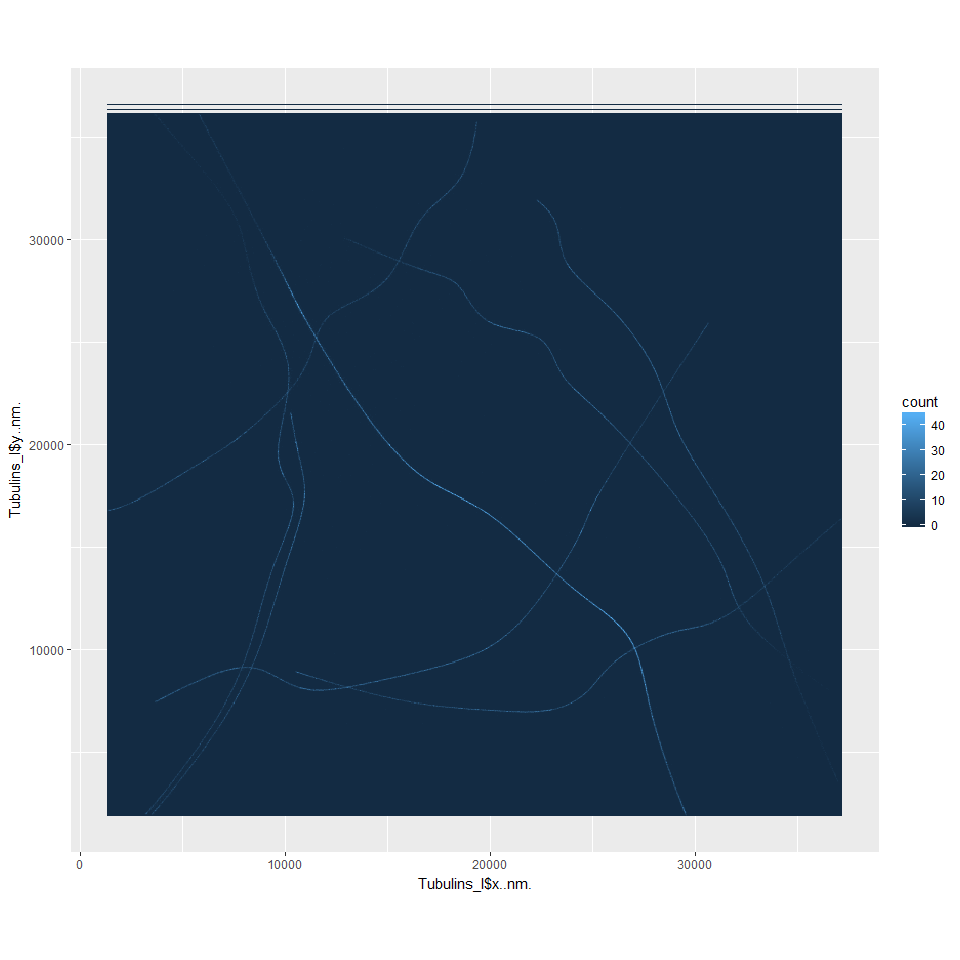

```r
library(ggplot2)
ggplot(Tubulins_I, aes(x=Tubulins_I$x..nm., y=Tubulins_I$y..nm.))+
  geom_bin2d(binwidth=50, drop = FALSE)+
  coord_fixed()
```

Notice the two transparent lines at the top of the plot. This is not entirely what I wanted. A bit of googling revealed that this has been [logged as an issue, but it is not actually a bug](https://github.com/tidyverse/ggplot2/issues/2202). I have therefore written (but not extensively tested!) a little utility function that uses the **raster** library to generate, in effect, a 2d histogram as a data frame which can then be plotted using **ggplot2**, so I can keep using all of the other good stuff in **ggplot2** with my localisation data.

```r
locs_to_image<-function(loc_x,loc_y,pixel_size_nm)
{
  library(raster)

  #find the minimum and maximum x and y coordinates
  xmin<-min(loc_x)
  xmax<-max(loc_x)

  ymin<-min(loc_y)
  ymax<-max(loc_y)

  #create a blank image of the appropriate dimensions and bin size (termed resolution)
  image<-raster(xmn=xmin,xmx=xmax,ymn=ymin,ymx=ymax,resolution=pixel_size_nm)

  xy<-data.frame(x_nm=loc_x,y_nm=loc_y)

  #build the 2d histogram
  #Explicitly setting the background to 0 means that pixels (bins) containing
  #no localisations will have a 0 rather than an NA. This helps with plotting.
  #Pixel values are the number of localisations in the bin.
  image<-rasterize(xy,image,fun=function(x,...)length(x),background=0)
  #Convert the image (2d histogram in table format) to a data frame.
  image_df<-as.data.frame(image, xy=TRUE)
  names(image_df)<-c("x_nm","y_nm","count")

  return(image_df)

}
```

I can then use this function to get a data frame which I can visualise using **geom_tile**.

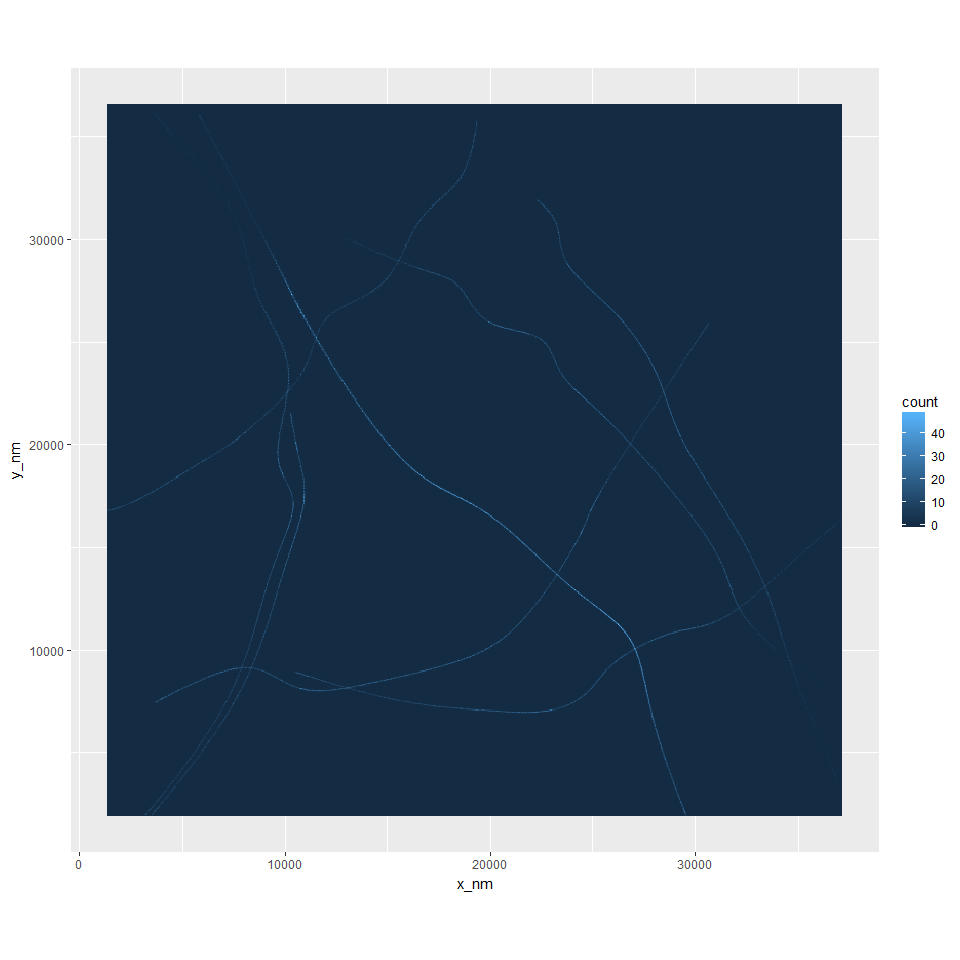

```r
image_df<-locs_to_image(Tubulins_I$x..nm.,Tubulins_I$y..nm.,50)
ggplot(image_df,aes(x=x_nm,y=y_nm))+
  geom_tile(aes(fill=count))+
  coord_fixed()
```

And no transparent lines.

See my [website](https://sites.google.com/view/robert-turner) for more examples. Contact me on bob dot turner dot uk at gmail dot com with comments or questions.